# 三、 数据预处理及模型建立、评估

# 1.导入数据集house_price.txt

```python
#用pandas导入数据集house_price.txt
import pandas as pd
data = pd.read_table("E:\DM2\house_price.txt",delim_whitespace=True)
#展示数据集前几个数值
print (data.head)
#展示数据集信息
print(data.info())
```

```
<bound method NDFrame.head of        total_price  room_num  hall_num    area  district  layer  orientation  \
0              250         1         0   37.60         0      6            1
1              360         2         1   51.49         2      6            1
2              345         2         1   44.39         2      6            1
3              445         2         1   56.79         0     12            1
4              320         2         1   41.66         2      6            1
5              315         1         1   43.81         1      6            1
6              278         1         0   38.92         0      6            1
7              385         2         1   55.57         0      6            1
8              485         2         1   69.05         0     24            1
9              316         2         0   46.56         1      6            1
10             260         1         1   39.53         2      6            1
11             288         1         1   39.36         1      6            1
12             220         1         1   35.32         2      6            1
13             370         2         1   54.00         0      6            1
```

[output cut: 197 more lines]

可以观察到数据集中有73306条有效数据，16个特征值，特征值中除area属性为float类型外，其余为int类型

```python
print(data.describe())
```

```
        total_price      room_num      hall_num          area      district  \
count  73306.000000  73306.000000  73306.000000  73306.000000  73306.000000
mean     557.157149      2.261779      1.476714     95.735702      1.135419
std      563.546757      0.949057      0.664317     67.258458      0.820984
min       48.000000      1.000000      0.000000     20.100000      0.000000
25%      290.000000      2.000000      1.000000     58.560000      0.000000
50%      400.000000      2.000000      2.000000     82.710000      1.000000
75%      630.000000      3.000000      2.000000    111.430000      2.000000
max    35000.000000      9.000000      9.000000   4588.000000      2.000000

              layer   orientation      location    build_time      price_per  \
count  73306.000000  73306.000000  73306.000000  73306.000000   73306.000000
mean      10.501296      0.853655      8.908575   1999.309620   57316.623128
std        7.836873      0.353455      4.563774      9.624029   21328.489238
min        1.000000      0.000000      1.000000   1911.000000    7628.000000
25%        6.000000      1.000000      4.000000   1994.000000   42121.000000
50%        6.000000      1.000000     10.000000   2000.000000   54993.000000
75%       14.000000      1.000000     13.000000   2006.000000   68548.750000
max       80.000000      1.000000     18.000000   2017.000000  199879.000000

             subway       balcony         light    bay_window    Decoration  \
count  73306.000000  73306.000000  73306.000000  73306.000000  73306.000000
mean       0.612146      0.390459      0.511773      0.059409      0.688347
std        0.487264      0.487857      0.499865      0.236389      0.805851
min        0.000000      0.000000      0.000000      0.000000      0.000000
25%        0.000000      0.000000      0.000000      0.000000      0.000000
50%        1.000000      0.000000      1.000000      0.000000      0.000000
75%        1.000000      1.000000      1.000000      0.000000      1.000000
max        1.000000      1.000000      1.000000      1.000000      2.000000

           elevator
count  73306.000000
mean       0.092762
std        0.290100
min        0.000000
25%        0.000000
50%        0.000000
75%        0.000000
max        1.000000
```

可以观察每列数据的标准差、最大值、最小值以及分位值,比如我们要预测的房价总值，均值为557万，最小值为48万，最大值为35000万，有25%的房价小于290万，50%的房子总价小于400万，75%的房子总价小于630万。

# 2. 特征分析独立分析

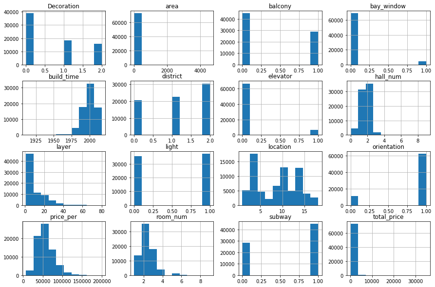

```python
#分析每个特征的取值范围以及分布情况，用直方图可视化
import matplotlib.pyplot as plt
data.hist(figsize=(15,10))#bins 柱子个数
plt.savefig('a.jpg')  #保存图片
plt.show()
```

因为price_per这一列和total_price这一列相关性很强，根据验证可知，total_price=price_per*area，所以可以在数据集中删掉price_per这一列

```python
#删去每平方米价格一列
import numpy as np
from pandas import Series, DataFrame
data_ind=data.drop(['price_per'],axis=1,inplace=False)
print(data_ind.head)
```

```
<bound method NDFrame.head of        total_price  room_num  hall_num    area  district  layer  orientation  \
0              250         1         0   37.60         0      6            1
1              360         2         1   51.49         2      6            1
2              345         2         1   44.39         2      6            1
3              445         2         1   56.79         0     12            1
4              320         2         1   41.66         2      6            1
5              315         1         1   43.81         1      6            1
6              278         1         0   38.92         0      6            1
7              385         2         1   55.57         0      6            1
8              485         2         1   69.05         0     24            1
9              316         2         0   46.56         1      6            1
10             260         1         1   39.53         2      6            1
11             288         1         1   39.36         1      6            1
12             220         1         1   35.32         2      6            1
13             370         2         1   54.00         0      6            1
```

[output cut: 175 more lines]

# 3. 划分测试集和训练集，以及分出属性和预测label

```python
#划分测试集
import sklearn
from sklearn.model_selection import train_test_split
data_train,data_test=train_test_split(data_ind,test_size=0.3)
X_train = data_train.iloc[:,1:15]
X_test = data_test.iloc[:,1:15]
y_train = data_train.iloc[:,0]
y_test = data_test.iloc[:,0]
#print(X_train)
##X_train,X_test,y_train,y_test=train_test_split(X,y,test_size=0.3)
```

# 4. 特征相关性分析

```python
##通过计算相关系数矩阵找出特征之间的相关性
corr_matrix = data_train.corr()
print(corr_matrix['total_price'].sort_values(ascending=False))
```

```
total_price    1.000000
area           0.781092
room_num       0.551551
hall_num       0.444651
layer          0.259405
build_time     0.191311
subway         0.081135
Decoration     0.037278
district       0.026189
bay_window     0.004229
elevator       0.000056
orientation   -0.024573
location      -0.073273
light         -0.174412
balcony       -0.186570
Name: total_price, dtype: float64
```

```
array([[<matplotlib.axes._subplots.AxesSubplot object at 0x000001BEDCA9E860>,
      dtype=object)
```

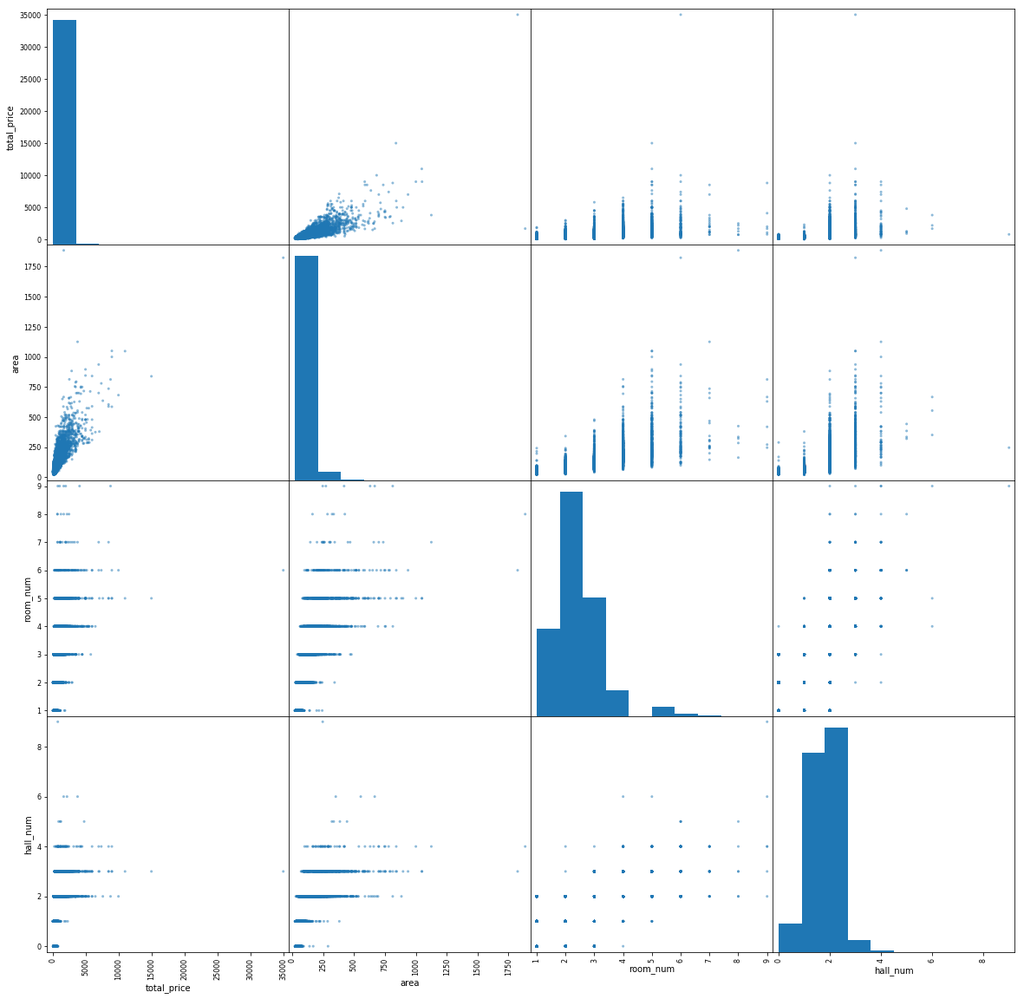

```python
##绘制相关系数最大的四个特征之间分布
from pandas.plotting import scatter_matrix
attribute = ['total_price','area','room_num','hall_num']
scatter_matrix(data_test[attribute],figsize=(20,20))
```

```python
# from sklearn.pipeline import FeatureUnion, _fit_one_transformer, _fit_transform_one, _transform_one
# from sklearn.externals.joblib import Parallel, delayed
# from scipy import sparse
# import numpy as np

# #部分并行处理，继承FeatureUnion
# class FeatureUnionExt(FeatureUnion):
#     #相比FeatureUnion，多了idx_list参数，其表示每个并行工作需要读取的特征矩阵的列
#     def __init__(self, transformer_list, idx_list, n_jobs=1, transformer_weights=None):
#         self.idx_list = idx_list
#         FeatureUnion.__init__(self, transformer_list=map(lambda trans:(trans[0], trans[1]), transformer_list), n_jobs=n_jobs, transformer_weights=transformer_weights)

#     #由于只部分读取特征矩阵，方法fit需要重构
#     def fit(self, X, y=None):
#         transformer_idx_list = map(lambda trans, idx:(trans[0], trans[1], idx), self.transformer_list, self.idx_list)
#         transformers = Parallel(n_jobs=self.n_jobs)(
#             #从特征矩阵中提取部分输入fit方法
#             delayed(_fit_one_transformer)(trans, X[:,idx], y)
#             for name, trans, idx in transformer_idx_list)
#         self._update_transformer_list(transformers)
#         return self

#     #由于只部分读取特征矩阵，方法fit_transform需要重构
#     def fit_transform(self, X, y=None, **fit_params):
#         transformer_idx_list = map(lambda trans, idx:(trans[0], trans[1], idx), self.transformer_list, self.idx_list)
#         result = Parallel(n_jobs=self.n_jobs)(
#             #从特征矩阵中提取部分输入fit_transform方法
#             delayed(_fit_transform_one)(trans, name, X[:,idx], y,
#                                         self.transformer_weights, **fit_params)
#             for name, trans, idx in transformer_idx_list)

#         Xs, transformers = zip(*result)
#         self._update_transformer_list(transformers)
#         if any(sparse.issparse(f) for f in Xs):
#             Xs = sparse.hstack(Xs).tocsr()
#         else:
#             Xs = np.hstack(Xs)
#         return Xs

#     #由于只部分读取特征矩阵，方法transform需要重构
#     def transform(self, X):
#         transformer_idx_list = map(lambda trans, idx:(trans[0], trans[1], idx), self.transformer_list, self.idx_list)
#         Xs = Parallel(n_jobs=self.n_jobs)(
#             #从特征矩阵中提取部分输入transform方法
#             delayed(_transform_one)(trans, name, X[:,idx], self.transformer_weights)
#             for name, trans, idx in transformer_idx_list)
#         if any(sparse.issparse(f) for f in Xs):
#             Xs = sparse.hstack(Xs).tocsr()
#         else:
#             Xs = np.hstack(Xs)
#         return Xs
```

```python
# #Durex编码和特征缩放
# from sklearn.preprocessing import OneHotEncoder
# from sklearn.preprocessing import StandardScaler
# a=['district','orientation','location','subway','balcony','light','bay_window','Decoration','elevator']
# # encoder = OneHotEncoder(categorical_features=['district','orientation','location','subway','balcony','light','bay_window','Decoration','elevator'],sparse=False)
# # data_dur= encoder.fit_transform(data_ind.values)
# step2_1 = ('OneHotEncoder', OneHotEncoder(sparse=False))
# step2_2 = ('StandardScaler',StandardScaler(copy=True, with_mean=True, with_std=True))
# step2 = ('FeatureUnionExt', FeatureUnionExt(transformer_list=[step2_1, step2_2], idx_list=[a,['area']]))
# #full_pipeline =  FeatureUnionExt(transformer_list=[step2_1, step2_2], idx_list=[a,['area']])
# print(step2)
```

# 5.数据预处理

## 1.离散特征独热编码

```python
from sklearn.preprocessing import OneHotEncoder
a=['district','orientation','location','subway','balcony','light','bay_window','Decoration','elevator']
encoder = OneHotEncoder(sparse=False)
train_cat_1hot = encoder.fit_transform(X_train[a])
test_cat_1hot = encoder.transform(X_test[a])
print(train_cat_1hot.dtype)
print(train_cat_1hot.shape)
print(train_cat_1hot)
print(test_cat_1hot.dtype)
print(test_cat_1hot.shape)
print(test_cat_1hot)
```

```
float64
(51314, 36)
[[0. 0. 1. ... 0. 1. 0.]
 [1. 0. 0. ... 1. 1. 0.]
 [0. 1. 0. ... 1. 1. 0.]
 ...
 [0. 0. 1. ... 0. 1. 0.]
 [0. 0. 1. ... 1. 1. 0.]
 [1. 0. 0. ... 0. 1. 0.]]
float64
(21992, 36)
[[0. 1. 0. ... 0. 1. 0.]
 [0. 0. 1. ... 0. 1. 0.]
 [0. 1. 0. ... 0. 1. 0.]
 ...
 [1. 0. 0. ... 0. 0. 1.]
 [0. 0. 1. ... 1. 1. 0.]
 [0. 0. 1. ... 0. 1. 0.]]
```

## 2.连续特征标准化

```python
from sklearn.preprocessing import StandardScaler
#print(X_train)
train_cat=pd.concat([X_train.iloc[:,0:3],X_train.iloc[:,4],X_train.iloc[:,7]],axis=1)
test_cat=pd.concat([X_test.iloc[:,0:3],X_test.iloc[:,4],X_test.iloc[:,7]],axis=1)
#print(train_cat)
scaler =StandardScaler()
train_cat_scaled = scaler.fit_transform(train_cat)
test_cat_scaled = scaler.transform(test_cat) #这里是transform,，StandardScaler只使用训练集fit一次，这样保证训练集和测试集使用相同的标准进行的特征缩放。
print(train_cat_scaled.shape)
print(train_cat_scaled.dtype)
print(train_cat_scaled)
print(test_cat_scaled.shape)
print(test_cat_scaled.dtype)
print(test_cat_scaled)
```

```
(51314, 5)
float64
[[-0.27390966  0.79009419  0.31744546  0.95220288  0.17745588]
 [-0.27390966  0.79009419 -0.74231748 -0.700498   -1.68360642]
 [-0.27390966  0.79009419  1.10246604  0.44367953 -7.78375506]
 ...
 [ 0.77924486 -0.71472703 -0.18763494 -0.57336716 -0.44289822]
 [ 0.77924486  0.79009419  0.20324174 -0.57336716 -0.44289822]
 [-1.32706417 -0.71472703 -0.53960218  2.47777292  0.48763293]]
(21992, 5)
float64
[[-1.32706417 -0.71472703 -0.88147077 -0.700498   -1.68360642]
 [ 0.77924486  0.79009419 -0.11828106 -0.44623632  1.21137938]
 [-0.27390966 -0.71472703 -0.31208581  1.46072623  0.07406353]
 ...
 [-0.27390966 -0.71472703 -0.4371307   0.95220288 -1.06325232]
 [ 0.77924486  0.79009419  0.62188968  0.95220288  0.07406353]
 [-1.32706417 -2.21954824 -0.96805174 -0.57336716 -0.54629057]]
```

## 3.合并最终的数据集

```python
#数据处理完合并成为最终的数据集
# print(np.array(X_train[a]).shape)
# print(np.array(X_train[a]).ndim)
# print(np.array(X_train[a]).dtype)
# c=np.array(X_train[a])
# print(c.astype(np.float64).dtype)
#X_train_final=np.concatenate((c.astype(np.float64),train_cat_scaled),axis=1)
X_train_final=np.concatenate((train_cat_1hot,train_cat_scaled),axis=1)
X_test_final=np.concatenate((test_cat_1hot,test_cat_scaled),axis=1)
print(X_train_final.shape)
print(X_train_final)
print(X_test_final.shape)
print(X_test_final)
```

```
(51314, 41)
[[ 0.          0.          1.         ...  0.31744546  0.95220288
   0.17745588]
 [ 1.          0.          0.         ... -0.74231748 -0.700498
  -1.68360642]
 [ 0.          1.          0.         ...  1.10246604  0.44367953
  -7.78375506]
 ...
 [ 0.          0.          1.         ... -0.18763494 -0.57336716
  -0.44289822]
 [ 0.          0.          1.         ...  0.20324174 -0.57336716
  -0.44289822]
 [ 1.          0.          0.         ... -0.53960218  2.47777292
   0.48763293]]
(21992, 41)
[[ 0.          1.          0.         ... -0.88147077 -0.700498
  -1.68360642]
 [ 0.          0.          1.         ... -0.11828106 -0.44623632
   1.21137938]
 [ 0.          1.          0.         ... -0.31208581  1.46072623
   0.07406353]
 ...
 [ 1.          0.          0.         ... -0.4371307   0.95220288
  -1.06325232]
 [ 0.          0.          1.         ...  0.62188968  0.95220288
   0.07406353]
 [ 0.          0.          1.         ... -0.96805174 -0.57336716
  -0.54629057]]
```

# 6.训练模型选择

## 1.线性回归

```python
#线性回归
from sklearn import metrics
from sklearn.linear_model import LinearRegression
model1 = LinearRegression()
model1.fit(X_train_final,y_train)
# 对测试集进行预测
ans = model1.predict(X_test_final)

#模型评估
from sklearn.metrics import mean_squared_error,mean_absolute_error,r2_score
#方差
print ("MSE",mean_squared_error(ans,y_test))
#平均绝对误差
print("MAE",mean_absolute_error(ans,y_test))
#R2分数
print("R2",r2_score(ans,y_test))

#可视化
print('Slope:%.3f' %model1.coef_[0])
print('Intercept: %.3f' %model1.intercept_)
```

[output not shown]

## 2.非线性回归

```python
#非线性回归
from sklearn.tree import DecisionTreeRegressor
model2 = DecisionTreeRegressor()
model2.fit(X_train_final,y_train)

# 对测试集进行预测
ans = model2.predict(X_test_final)

#模型评估
from sklearn.metrics import mean_squared_error,mean_absolute_error,r2_score
#方差
print ("MSE",mean_squared_error(ans,y_test))
#平均绝对误差
print("MAE",mean_absolute_error(ans,y_test))
#R2分数
print("R2",r2_score(ans,y_test))
```

```
MSE 100813.08822273756
MAE 112.72736298047774
R2 0.6817544365083501
```

## 3.随机森林

```
MSE 87013.72988908715
MAE 91.14940809284184
R2 0.6789189665599741
```

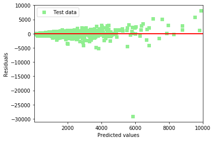

```python
#随机森林
from sklearn.ensemble import RandomForestRegressor
forest=RandomForestRegressor()
forest.fit(X_train_final,y_train)
# 对测试集进行预测
ans = forest.predict(X_test_final)

#模型评估
from sklearn.metrics import mean_squared_error,mean_absolute_error,r2_score
#方差
print ("MSE",mean_squared_error(ans,y_test))
#平均绝对误差
print("MAE",mean_absolute_error(ans,y_test))
#R2分数
print("R2",r2_score(ans,y_test))

plt.scatter(ans,ans - y_test,c='lightgreen',marker='s',label='Test data')
plt.xlabel('Predicted values')
plt.ylabel('Residuals')
plt.legend(loc='upper left')
plt.hlines(y=0,xmin=40,xmax=10000,lw=2,color='red')
plt.xlim([40,10000])
plt.tight_layout()
plt.show()
```

## 4.XGBoost

```
MSE 75368.72965092638
MAE 112.2847109926792
R2 0.7084049619835303
```

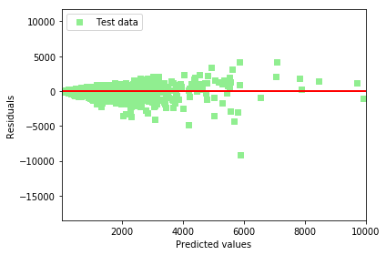

```python
#XGBoost模型
import xgboost as xgb
xlf = xgb.XGBRegressor()
xlf.fit(X_train_final,y_train)
# 对测试集进行预测
ans = xlf.predict(X_test_final)

#模型评估
from sklearn.metrics import mean_squared_error,mean_absolute_error,r2_score
#方差
print ("MSE",mean_squared_error(ans,y_test))
#平均绝对误差
print("MAE",mean_absolute_error(ans,y_test))
#R2分数
print("R2",r2_score(ans,y_test))

plt.scatter(ans,ans - y_test,c='lightgreen',marker='s',label='Test data')
plt.xlabel('Predicted values')
plt.ylabel('Residuals')
plt.legend(loc='upper left')
plt.hlines(y=0,xmin=40,xmax=10000,lw=2,color='red')
plt.xlim([40,10000])
plt.tight_layout()
plt.show()
```

根据r2参数来看，XGBoost的训练效果相对好一些，随机森林的平均误差好一些，Xgboost的方差好一些，考虑到上次作业使用了随机森林，这次考虑使用XGBoost的模型，下面调整参数以获得更好的效果。

# 7.用训练集对XGBoost模型调参

## 1.基本参数设置

```python
 # XGBoost训练过程
import xgboost as xgb
from xgboost import plot_importance
from matplotlib import pyplot as plt
from sklearn.model_selection import train_test_split
from sklearn.grid_search import GridSearchCV
#模型参数设置
xlf = xgb.XGBRegressor(max_depth=5,
                        learning_rate=0.1,
                        n_estimators=100,
                        silent=True,
                        objective='reg:linear',
                        nthread=-1,
                        gamma=0,
                        min_child_weight=1,
                        max_delta_step=0,
                        subsample=0.85,
                        colsample_bytree=0.8,
                        colsample_bylevel=1,
                        reg_alpha=0,
                        reg_lambda=1,
                        scale_pos_weight=1,
                        seed=0,
                        missing=None)

xlf.fit(X_train_final, y_train)
print(xlf)
print("R2",r2_score(ans,y_test))
```

```
XGBRegressor(base_score=0.5, booster='gbtree', colsample_bylevel=1,
       colsample_bytree=0.8, gamma=0, learning_rate=0.1, max_delta_step=0,
       max_depth=5, min_child_weight=1, missing=None, n_estimators=100,
       n_jobs=1, nthread=-1, objective='reg:linear', random_state=0,
       reg_alpha=0, reg_lambda=1, scale_pos_weight=1, seed=0, silent=True,
       subsample=0.85)
R2 0.7084049619835303
```

## 2.最佳迭代次数n_estimators,范围在400-800，结果在800的时候效果最好，但时间较长

```python
from sklearn.grid_search import GridSearchCV
cv_params = {'n_estimators': [400, 500, 600, 700, 800]}
other_params = {'learning_rate': 0.1, 'n_estimators': 500, 'max_depth': 5, 'min_child_weight': 1, 'seed': 0,
                    'subsample': 0.8, 'colsample_bytree': 0.8, 'gamma': 0, 'reg_alpha': 0, 'reg_lambda': 1}
model = xgb.XGBRegressor(**other_params)
optimized_GBM = GridSearchCV(estimator=model, param_grid=cv_params, scoring='r2', cv=5, verbose=1, n_jobs=4)
optimized_GBM.fit(X_train_final, y_train)
evalute_result = optimized_GBM.grid_scores_
print('每轮迭代运行结果:{0}'.format(evalute_result))
print('参数的最佳取值：{0}'.format(optimized_GBM.best_params_))
print('最佳模型得分:{0}'.format(optimized_GBM.best_score_))
```

```
Fitting 5 folds for each of 5 candidates, totalling 25 fits
```

```
[Parallel(n_jobs=4)]: Done  25 out of  25 | elapsed:  6.3min finished
```

```
每轮迭代运行结果:[mean: 0.82805, std: 0.04405, params: {'n_estimators': 400}, mean: 0.82904, std: 0.04402, params: {'n_estimators': 500}, mean: 0.82978, std: 0.04416, params: {'n_estimators': 600}, mean: 0.83020, std: 0.04404, params: {'n_estimators': 700}, mean: 0.83052, std: 0.04395, params: {'n_estimator…
参数的最佳取值：{'n_estimators': 800}
最佳模型得分:0.8305197979055752
```

考虑最佳迭代次数n_estimators,范围在10-50，结果50时效果最好

```python
#最佳迭代次数n_estimators
from sklearn.grid_search import GridSearchCV
cv_params = {'n_estimators': [10,20,30,40,50]}
other_params = {'learning_rate': 0.1, 'n_estimators': 300, 'max_depth': 5, 'min_child_weight': 1, 'seed': 0,
                    'subsample': 0.8, 'colsample_bytree': 0.8, 'gamma': 0, 'reg_alpha': 0, 'reg_lambda': 1}
model = xgb.XGBRegressor(**other_params)
optimized_GBM = GridSearchCV(estimator=model, param_grid=cv_params, scoring='r2', cv=5, verbose=1, n_jobs=4)
optimized_GBM.fit(X_train_final, y_train)
evalute_result = optimized_GBM.grid_scores_
print('每轮迭代运行结果:{0}'.format(evalute_result))
print('参数的最佳取值：{0}'.format(optimized_GBM.best_params_))
print('最佳模型得分:{0}'.format(optimized_GBM.best_score_))
```

```
Fitting 5 folds for each of 5 candidates, totalling 25 fits
```

```
[Parallel(n_jobs=4)]: Done  25 out of  25 | elapsed:   20.2s finished
```

```
每轮迭代运行结果:[mean: 0.50590, std: 0.01223, params: {'n_estimators': 10}, mean: 0.73438, std: 0.01819, params: {'n_estimators': 20}, mean: 0.78422, std: 0.02617, params: {'n_estimators': 30}, mean: 0.79990, std: 0.03185, params: {'n_estimators': 40}, mean: 0.80420, std: 0.03689, params: {'n_estimators': …
参数的最佳取值：{'n_estimators': 50}
最佳模型得分:0.8041958455635226
```

继续考虑最佳迭代次数n_estimators,范围在100-300，结果300时效果最好

```python
#最佳迭代次数n_estimators
from sklearn.grid_search import GridSearchCV
#from sklearn import grid_search
cv_params = {'n_estimators': [100,200,300]}
other_params = {'learning_rate': 0.1, 'n_estimators': 300, 'max_depth': 5, 'min_child_weight': 1, 'seed': 0,
                    'subsample': 0.8, 'colsample_bytree': 0.8, 'gamma': 0, 'reg_alpha': 0, 'reg_lambda': 1}
model = xgb.XGBRegressor(**other_params)
optimized_GBM = GridSearchCV(estimator=model, param_grid=cv_params, scoring='r2', cv=5, verbose=1, n_jobs=4)
optimized_GBM.fit(X_train_final, y_train)
evalute_result = optimized_GBM.grid_scores_
print('每轮迭代运行结果:{0}'.format(evalute_result))
print('参数的最佳取值：{0}'.format(optimized_GBM.best_params_))
print('最佳模型得分:{0}'.format(optimized_GBM.best_score_))
```

```
Fitting 5 folds for each of 3 candidates, totalling 15 fits
```

```
[Parallel(n_jobs=4)]: Done  15 out of  15 | elapsed:  1.2min finished
```

```
每轮迭代运行结果:[mean: 0.81367, std: 0.04591, params: {'n_estimators': 100}, mean: 0.82289, std: 0.04466, params: {'n_estimators': 200}, mean: 0.82629, std: 0.04388, params: {'n_estimators': 300}]
参数的最佳取值：{'n_estimators': 300}
最佳模型得分:0.8262946825068367
```

综合考虑到运行时间和训练效果，所以选用300

## 2.参数max_depth

```python
cv_params = {'max_depth': [3, 4, 5, 6, 7, 8]}
other_params = {'learning_rate': 0.1, 'n_estimators': 300, 'max_depth': 5, 'min_child_weight': 1, 'seed': 0,
                    'subsample': 0.8, 'colsample_bytree': 0.8, 'gamma': 0, 'reg_alpha': 0, 'reg_lambda': 1}
model = xgb.XGBRegressor(**other_params)
optimized_GBM = GridSearchCV(estimator=model, param_grid=cv_params, scoring='r2', cv=5, verbose=1, n_jobs=4)
optimized_GBM.fit(X_train_final, y_train)
evalute_result = optimized_GBM.grid_scores_
print('每轮迭代运行结果:{0}'.format(evalute_result))
print('参数的最佳取值：{0}'.format(optimized_GBM.best_params_))
print('最佳模型得分:{0}'.format(optimized_GBM.best_score_))
```

```
Fitting 5 folds for each of 6 candidates, totalling 30 fits
```

```
[Parallel(n_jobs=4)]: Done  30 out of  30 | elapsed:  4.0min finished
```

```
每轮迭代运行结果:[mean: 0.80291, std: 0.04976, params: {'max_depth': 3}, mean: 0.81784, std: 0.04662, params: {'max_depth': 4}, mean: 0.82629, std: 0.04388, params: {'max_depth': 5}, mean: 0.83198, std: 0.04469, params: {'max_depth': 6}, mean: 0.83332, std: 0.04205, params: {'max_depth': 7}, mean: 0.83718, …
参数的最佳取值：{'max_depth': 8}
最佳模型得分:0.837181166857593
```

## 3.参数min_child_weight

```python
cv_params = {'min_child_weight': [1, 2, 3, 4, 5]}
other_params = {'learning_rate': 0.1, 'n_estimators': 300, 'max_depth': 8, 'min_child_weight': 1, 'seed': 0,
                    'subsample': 0.8, 'colsample_bytree': 0.8, 'gamma': 0, 'reg_alpha': 0, 'reg_lambda': 1}
model = xgb.XGBRegressor(**other_params)
optimized_GBM = GridSearchCV(estimator=model, param_grid=cv_params, scoring='r2', cv=5, verbose=1, n_jobs=4)
optimized_GBM.fit(X_train_final, y_train)
evalute_result = optimized_GBM.grid_scores_
print('每轮迭代运行结果:{0}'.format(evalute_result))
print('参数的最佳取值：{0}'.format(optimized_GBM.best_params_))
print('最佳模型得分:{0}'.format(optimized_GBM.best_score_))
```

```
Fitting 5 folds for each of 5 candidates, totalling 25 fits
```

```
[Parallel(n_jobs=4)]: Done  25 out of  25 | elapsed:  5.8min finished
```

```
每轮迭代运行结果:[mean: 0.83718, std: 0.03997, params: {'min_child_weight': 1}, mean: 0.83661, std: 0.02129, params: {'min_child_weight': 2}, mean: 0.83436, std: 0.01578, params: {'min_child_weight': 3}, mean: 0.83541, std: 0.01803, params: {'min_child_weight': 4}, mean: 0.83604, std: 0.00841, params: {'min…
参数的最佳取值：{'min_child_weight': 1}
最佳模型得分:0.837181166857593
```

## 4.调参数gamma

```python
cv_params = {'gamma': [0,0.1, 0.2, 0.3, 0.4, 0.5, 0.6]}
other_params = {'learning_rate': 0.1, 'n_estimators': 300, 'max_depth': 8, 'min_child_weight': 1, 'seed': 0,
                    'subsample': 0.8, 'colsample_bytree': 0.8, 'gamma': 0, 'reg_alpha': 0, 'reg_lambda': 1}
model = xgb.XGBRegressor(**other_params)
optimized_GBM = GridSearchCV(estimator=model, param_grid=cv_params, scoring='r2', cv=5, verbose=1, n_jobs=4)
optimized_GBM.fit(X_train_final, y_train)
evalute_result = optimized_GBM.grid_scores_
print('每轮迭代运行结果:{0}'.format(evalute_result))
print('参数的最佳取值：{0}'.format(optimized_GBM.best_params_))
print('最佳模型得分:{0}'.format(optimized_GBM.best_score_))
```

```
Fitting 5 folds for each of 7 candidates, totalling 35 fits
```

```
[Parallel(n_jobs=4)]: Done  35 out of  35 | elapsed:  8.4min finished
```

```
每轮迭代运行结果:[mean: 0.83718, std: 0.03997, params: {'gamma': 0}, mean: 0.83718, std: 0.03997, params: {'gamma': 0.1}, mean: 0.83730, std: 0.04001, params: {'gamma': 0.2}, mean: 0.83735, std: 0.04001, params: {'gamma': 0.3}, mean: 0.83733, std: 0.04005, params: {'gamma': 0.4}, mean: 0.83733, std: 0.04005…
参数的最佳取值：{'gamma': 0.3}
最佳模型得分:0.837353062772207
```

## 5.调参数subsample,colsample_bytree

```python
cv_params = {'subsample': [0.6, 0.7, 0.8, 0.9], 'colsample_bytree': [0.6, 0.7, 0.8, 0.9]}
other_params = {'learning_rate': 0.1, 'n_estimators': 300, 'max_depth': 8, 'min_child_weight': 1, 'seed': 0,
                    'subsample': 0.8, 'colsample_bytree': 0.8, 'gamma': 0.3, 'reg_alpha': 0, 'reg_lambda': 1}
model = xgb.XGBRegressor(**other_params)
optimized_GBM = GridSearchCV(estimator=model, param_grid=cv_params, scoring='r2', cv=5, verbose=1, n_jobs=4)
optimized_GBM.fit(X_train_final, y_train)
evalute_result = optimized_GBM.grid_scores_
print('每轮迭代运行结果:{0}'.format(evalute_result))
print('参数的最佳取值：{0}'.format(optimized_GBM.best_params_))
print('最佳模型得分:{0}'.format(optimized_GBM.best_score_))
```

```
Fitting 5 folds for each of 16 candidates, totalling 80 fits
```

```
[Parallel(n_jobs=4)]: Done  42 tasks      | elapsed:  9.1min
[Parallel(n_jobs=4)]: Done  80 out of  80 | elapsed: 18.0min finished
```

```
每轮迭代运行结果:[mean: 0.84530, std: 0.02454, params: {'colsample_bytree': 0.6, 'subsample': 0.6}, mean: 0.84308, std: 0.01987, params: {'colsample_bytree': 0.6, 'subsample': 0.7}, mean: 0.84200, std: 0.01924, params: {'colsample_bytree': 0.6, 'subsample': 0.8}, mean: 0.84485, std: 0.02138, params: {'colsa…
参数的最佳取值：{'colsample_bytree': 0.6, 'subsample': 0.6}
最佳模型得分:0.8452982893855446
```